# 18110213_DaoNgocPhuongThanh_ DM Lab06

```python
import pandas as pd
import numpy as np
import matplotlib.pyplot as plt
import seaborn as sns
from sklearn import metrics
```

```python
data=pd.read_csv(r'C:\Users\Thanh\Documents\Data mining\Data_Mining_Lab06\insurance.csv')
data.head()
```

|  | age | sex | bmi | children | smoker | region | charges |
| --- | --- | --- | --- | --- | --- | --- | --- |
| 0 | 19 | female | 27.900 | 0 | yes | southwest | 16884.92400 |
| 1 | 18 | male | 33.770 | 1 | no | southeast | 1725.55230 |
| 2 | 28 | male | 33.000 | 3 | no | southeast | 4449.46200 |
| 3 | 33 | male | 22.705 | 0 | no | northwest | 21984.47061 |
| 4 | 32 | male | 28.880 | 0 | no | northwest | 3866.85520 |

```python
data.info()
```

```
<class 'pandas.core.frame.DataFrame'>
RangeIndex: 1338 entries, 0 to 1337
Data columns (total 7 columns):
 #   Column    Non-Null Count  Dtype
---  ------    --------------  -----
 0   age       1338 non-null   int64
 1   sex       1338 non-null   object
 2   bmi       1338 non-null   float64
 3   children  1338 non-null   int64
 4   smoker    1338 non-null   object
 5   region    1338 non-null   object
 6   charges   1338 non-null   float64
dtypes: float64(2), int64(2), object(3)
memory usage: 73.3+ KB
```

Không có missing values

```python
data.describe()
```

|  | age | bmi | children | charges |
| --- | --- | --- | --- | --- |
| count | 1338.000000 | 1338.000000 | 1338.000000 | 1338.000000 |
| mean | 39.207025 | 30.663397 | 1.094918 | 13270.422265 |
| std | 14.049960 | 6.098187 | 1.205493 | 12110.011237 |
| min | 18.000000 | 15.960000 | 0.000000 | 1121.873900 |
| 25% | 27.000000 | 26.296250 | 0.000000 | 4740.287150 |
| 50% | 39.000000 | 30.400000 | 1.000000 | 9382.033000 |
| 75% | 51.000000 | 34.693750 | 2.000000 | 16639.912515 |
| max | 64.000000 | 53.130000 | 5.000000 | 63770.428010 |

### Data Exploration

##### Charges by age and sex

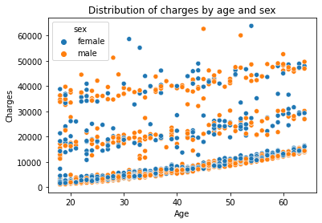

```python
sns.scatterplot(x = "age", y = "charges", data = data, hue = "sex")
plt.xlabel("Age")
plt.ylabel("Charges")
plt.title("Distribution of charges by age and sex")
```

Có thể thấy độ tuổi càng cao thì các charges càng tăng. Charges không bị ảnh hưởng bởi giới tính

##### Charges by smoker and BMI

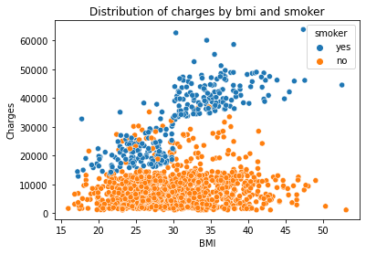

```python
sns.scatterplot(x = "bmi", y = "charges", data = data, hue = "smoker")
plt.xlabel("BMI")
plt.ylabel("Charges")
plt.title("Distribution of charges by bmi and smoker")
```

Người không hút thuốc thường có charges dưới 30000. Ngược lại người hút thuốc có xu hướng phải trả charges cao hơn, khi BMI của người hút thuốc > 30, mức charges tối thiểu là 30000.

##### Charges by region and sex

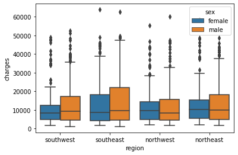

```python
sns.boxplot(x = "region", y = "charges", hue = "sex", data = data)
```

Các regions đều trả các mức phí khá tương đồng.

##### Charges by age and smoker

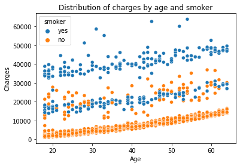

```python
sns.scatterplot(x = "age", y = "charges", data = data, hue = "smoker")
plt.xlabel("Age")
plt.ylabel("Charges")
plt.title("Distribution of charges by age and smoker")
```

Bất kì độ tuổi nào nếu hút thuốc thì thường bị tính phí cao hơn người không hút thuốc và thường phải trả trên 30000.

##### Charges by smoker and number of children

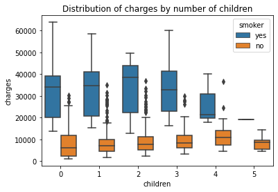

```python
sns.boxplot(x = "children", y = "charges",hue = "smoker", data = data)
plt.title("Distribution of charges by number of children")
```

Hút thuốc chắc chắn là một đặc điểm quan trọng cần lưu ý trong người mẫu.

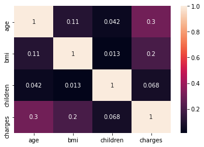

```python
sns.heatmap(data.corr(), annot = True)
```

Không có mối tương quan giữa các feature.

```python
# Transforming categorical features to numerical values
data["smoker"] = data["smoker"].replace(["yes","no"], [1,0])
data["sex"] = data["sex"].replace(["male","female"], [1,0])
#data["region_southeast"] = data["region"].apply(lambda x: 1 if x == "southeast" else 0)
data["region-num"] = data["region"].replace(["southeast","southwest","northwest","northeast"], [0,1,2,3])
```

```python
data
```

|  | age | sex | bmi | children | smoker | region | charges | region-num |
| --- | --- | --- | --- | --- | --- | --- | --- | --- |
| 0 | 19 | 0 | 27.900 | 0 | 1 | southwest | 16884.92400 | 1 |
| 1 | 18 | 1 | 33.770 | 1 | 0 | southeast | 1725.55230 | 0 |
| 2 | 28 | 1 | 33.000 | 3 | 0 | southeast | 4449.46200 | 0 |
| 3 | 33 | 1 | 22.705 | 0 | 0 | northwest | 21984.47061 | 2 |
| 4 | 32 | 1 | 28.880 | 0 | 0 | northwest | 3866.85520 | 2 |
| ... | ... | ... | ... | ... | ... | ... | ... | ... |
| 1333 | 50 | 1 | 30.970 | 3 | 0 | northwest | 10600.54830 | 2 |
| 1334 | 18 | 0 | 31.920 | 0 | 0 | northeast | 2205.98080 | 3 |
| 1335 | 18 | 0 | 36.850 | 0 | 0 | southeast | 1629.83350 | 0 |
| 1336 | 21 | 0 | 25.800 | 0 | 0 | southwest | 2007.94500 | 1 |
| 1337 | 61 | 0 | 29.070 | 0 | 1 | northwest | 29141.36030 | 2 |

1338 rows × 8 columns

Smoker: 1: Yes ; 0: No

Sex: 1: Male ; 0: Female

##### Feature Scaling

```python
# spliting training and testing data
from sklearn.model_selection import train_test_split

y = data["charges"]
X = data.drop(["charges","region"], axis = 1)
X_train, X_test, y_train, y_test = train_test_split(X,y,test_size=0.2,random_state=27)
```

```python
# data normalization with sklearn
from sklearn.preprocessing import MinMaxScaler

# copy of datasets
X_train_norm = X_train.copy()
X_test_norm = X_test.copy()

# apply standardization on numerical features

# fit scaler on training data
norm = MinMaxScaler().fit(X_train_norm)
# transform the training data column
X_train_norm = norm.transform(X_train_norm)
# transform the testing data column
X_test_norm = norm.transform(X_test_norm)
```

```python
# data standardization with  sklearn
from sklearn.preprocessing import StandardScaler

# copy of datasets
X_train_stand = X_train.copy()
X_test_stand = X_test.copy()

# apply standardization on numerical features
# fit on training data column
scale = StandardScaler().fit(X_train_stand)
# transform the training data column
X_train_stand = scale.transform(X_train_stand)
# transform the testing data column
X_test_stand = scale.transform(X_test_stand)
```

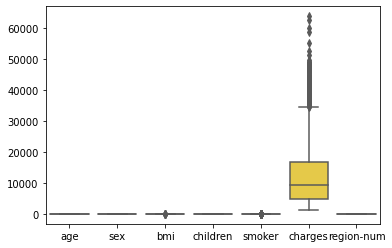

```python
sns.boxplot(data=data, orient="v", palette="Set2")
```

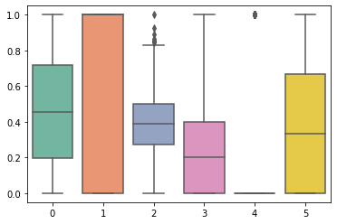

```python
sns.boxplot(data=X_train_norm, orient="v", palette="Set2")
```

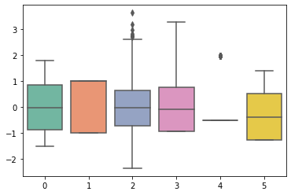

```python
sns.boxplot(data=X_train_stand, orient="v", palette="Set2")
```

### KNN Regression

```python
# training a KNN model
from sklearn.neighbors import KNeighborsRegressor
# measuring RMSE score
from sklearn.metrics import mean_squared_error

# knn
knn = KNeighborsRegressor(n_neighbors=10)
rmse = []

# raw, normalized and standardized training and testing data
trainX = [X_train, X_train_norm, X_train_stand]
testX = [X_test, X_test_norm, X_test_stand]

# model fitting and measuring RMSE
for i in range(len(trainX)):
    # fit
    knn.fit(trainX[i],y_train)
    # predict
    pred = knn.predict(testX[i])
    # RMSE
    rmse.append(np.sqrt(mean_squared_error(y_test,pred)))

# visualizing the result
df_knn = pd.DataFrame({'RMSE':rmse},index=['Original','Normalized','Standardized'])
df_knn
```

|  | RMSE |
| --- | --- |
| Original | 11272.981658 |
| Normalized | 6176.804751 |
| Standardized | 5712.923389 |

```python
from sklearn.model_selection import GridSearchCV
params = {'n_neighbors':range(2,20)}

knn = KNeighborsRegressor()

model = GridSearchCV(knn, params, cv=5)
model.fit(X_train_stand,y_train)
model.best_params_
```

```
{'n_neighbors': 8}
```

```python
# knn
knn = KNeighborsRegressor(n_neighbors=8)

knn.fit(X_train_stand, y_train)
y_pred = knn.predict(X_test_stand)

from sklearn.metrics import accuracy_score
knn.score(X_test_stand, y_test)
```

```
0.7806856979321213
```

### Decision Tree Regression

```python
# training a Decision Tree model
from sklearn.tree import DecisionTreeRegressor

# Decision tree
dt = DecisionTreeRegressor(max_depth=8,random_state=30)

rmse = []

# raw, normalized and standardized training and testing data
trainX = [X_train,X_train_norm,X_train_stand]
testX = [X_test,X_test_norm,X_test_stand]

# model fitting and measuring RMSE
for i in range(len(trainX)):

    # fit
    dt.fit(trainX[i],y_train)
    # predict
    pred = dt.predict(testX[i])
    # RMSE
    rmse.append(np.sqrt(mean_squared_error(y_test,pred)))

# visualizing the result
df_dt = pd.DataFrame({'RMSE':rmse},index=['Original','Normalized','Standardized'])
df_dt
```

|  | RMSE |
| --- | --- |
| Original | 6350.927632 |
| Normalized | 6335.101287 |
| Standardized | 6350.927632 |

```python
dt = DecisionTreeRegressor()

gs = GridSearchCV(dt,
                  param_grid = {'max_depth': range(1, 20),
                                'random_state': range(1, 30)},
                  cv=5,
                  n_jobs=1,
                  scoring='neg_mean_squared_error')

gs.fit(X_train_norm, y_train)

print(gs.best_params_)
```

```
{'max_depth': 4, 'random_state': 1}
```

```python
dt = DecisionTreeRegressor(max_depth=4,random_state=1)
dt.fit(X_train_norm,y_train)
y_pred=dt.predict(X_test)

from sklearn.metrics import accuracy_score
dt.score(X_test_norm, y_test)
```

```
0.8196521865765429
```

### Random Forest Regression

```python
from sklearn.ensemble import RandomForestRegressor

# Random Forest
rf = RandomForestRegressor()
rmse = []

# raw, normalized and standardized training and testing data
trainX = [X_train,X_train_norm,X_train_stand]
testX = [X_test,X_test_norm,X_test_stand]

# model fitting and measuring RMSE
for i in range(len(trainX)):
    # fit
    rf.fit(trainX[i],y_train)
    # predict
    pred = rf.predict(testX[i])
    # RMSE
    rmse.append(np.sqrt(mean_squared_error(y_test,pred)))

# visualizing the result
df_rf = pd.DataFrame({'RMSE':rmse},index=['Original','Normalized','Standardized'])
df_rf
```

|  | RMSE |
| --- | --- |
| Original | 5408.662615 |
| Normalized | 5530.930167 |
| Standardized | 5455.504630 |

```python
# Create the parameter grid based on the results of random search
param_grid = {
    'bootstrap': [True],
    'max_depth': [80, 90, 100, 110],
    'max_features': [2, 3],
    'min_samples_leaf': [3, 4, 5],
    'min_samples_split': [8, 10, 12],
    'n_estimators': [100, 200, 300, 1000]
}
# Create a based model
rf = RandomForestRegressor()
# Instantiate the grid search model
gs = GridSearchCV(estimator = rf, param_grid = param_grid,
                          cv = 3, n_jobs = -1, verbose = 2)
gs.fit(X_train, y_train)
print(gs.best_params_)
```

```
Fitting 3 folds for each of 288 candidates, totalling 864 fits
{'bootstrap': True, 'max_depth': 80, 'max_features': 3, 'min_samples_leaf': 4, 'min_samples_split': 10, 'n_estimators': 100}
```

```python
rf = RandomForestRegressor(bootstrap= True, max_depth= 80, max_features= 3,
                           min_samples_leaf= 4, min_samples_split= 10, n_estimators= 200)
rf.fit(X_train,y_train)
y_pred=rf.predict(X_train)

from sklearn.metrics import accuracy_score
rf.score(X_test, y_test)
```

```
0.8238715103884358
```

### Linear Regression

```python
from sklearn.linear_model import LinearRegression

# Linear Regression
lr = LinearRegression()
rmse = []

# raw, normalized and standardized training and testing data
trainX = [X_train,X_train_norm,X_train_stand]
testX = [X_test,X_test_norm,X_test_stand]

# model fitting and measuring RMSE
for i in range(len(trainX)):
    # fit
    lr.fit(trainX[i],y_train)
    # predict
    pred = lr.predict(testX[i])
    # RMSE
    rmse.append(np.sqrt(mean_squared_error(y_test,pred)))

# visualizing the result
df_lr = pd.DataFrame({'RMSE':rmse},index=['Original','Normalized','Standardized'])
df_lr
```

|  | RMSE |
| --- | --- |
| Original | 6281.431951 |
| Normalized | 6281.431951 |
| Standardized | 6281.431951 |

```python
lr = LinearRegression()
lr.fit(X_train,y_train)
y_pred=lr.predict(X_train)

from sklearn.metrics import accuracy_score
lr.score(X_test, y_test)
```

```
0.7319483730226098
```

### Ridge

```python
from sklearn.linear_model import Ridge

# Ridge
ridge = Ridge()
rmse = []

# raw, normalized and standardized training and testing data
trainX = [X_train,X_train_norm,X_train_stand]
testX = [X_test,X_test_norm,X_test_stand]

# model fitting and measuring RMSE
for i in range(len(trainX)):
    # fit
    ridge.fit(trainX[i],y_train)
    # predict
    pred = ridge.predict(testX[i])
    # RMSE
    rmse.append(np.sqrt(mean_squared_error(y_test,pred)))

# visualizing the result
df_ridge = pd.DataFrame({'RMSE':rmse},index=['Original','Normalized','Standardized'])
df_ridge
```

|  | RMSE |
| --- | --- |
| Original | 6279.238577 |
| Normalized | 6285.761774 |
| Standardized | 6281.443465 |

```python
# find optimal alpha with grid search
alpha = [0.001, 0.01, 0.1, 1, 10, 100, 1000]
param_grid = dict(alpha=alpha)
grid = GridSearchCV(estimator=ridge, param_grid=param_grid, scoring='r2', verbose=1, n_jobs=-1)
grid_result = grid.fit(X_train, y_train)
print('Best Params: ', grid_result.best_params_)
print('Best Score: ', grid_result.best_score_)
```

```
Fitting 5 folds for each of 7 candidates, totalling 35 fits
Best Params:  {'alpha': 1}
Best Score:  0.7482329428190946
```

### Lasso Regression

```python
from sklearn.linear_model import Lasso

# Lasso
lasso = Lasso()
rmse = []

# raw, normalized and standardized training and testing data
trainX = [X_train,X_train_norm,X_train_stand]
testX = [X_test,X_test_norm,X_test_stand]

# model fitting and measuring RMSE
for i in range(len(trainX)):
    # fit
    lasso.fit(trainX[i],y_train)
    # predict
    pred = lasso.predict(testX[i])
    # RMSE
    rmse.append(np.sqrt(mean_squared_error(y_test,pred)))

# visualizing the result
df_lasso = pd.DataFrame({'RMSE':rmse},index=['Original','Normalized','Standardized'])
df_lasso
```

|  | RMSE |
| --- | --- |
| Original | 6281.420351 |
| Normalized | 6282.395900 |
| Standardized | 6281.661027 |

```python
# find optimal alpha with grid search
alpha = [0.001, 0.01, 0.1, 1, 10, 100, 1000]
param_grid = dict(alpha=alpha)
grid = GridSearchCV(estimator=lasso, param_grid=param_grid, scoring='r2', verbose=1, n_jobs=-1)
grid_result = grid.fit(X_train, y_train)
print('Best Params: ', grid_result.best_params_)
print('Best Score: ', grid_result.best_score_)
```

```
Fitting 5 folds for each of 7 candidates, totalling 35 fits
Best Params:  {'alpha': 10}
Best Score:  0.7482088945361989
```

### Polynomial Regression

```python
from sklearn.preprocessing import PolynomialFeatures
from sklearn.pipeline import Pipeline
# Polynomial Features
poly = Pipeline([("poly", PolynomialFeatures(degree=2)),
                 ("std_scaler", StandardScaler()),
                 ("lin_reg",LinearRegression())
                ])
rmse = []

# raw, normalized and standardized training and testing data
trainX = [X_train,X_train_norm,X_train_stand]
testX = [X_test,X_test_norm,X_test_stand]

# model fitting and measuring RMSE
for i in range(len(trainX)):
    # fit
    poly.fit(trainX[i],y_train)
    # predict
    pred = poly.predict(testX[i])
    # RMSE
    rmse.append(np.sqrt(mean_squared_error(y_test,pred)))

# visualizing the result
df_poly = pd.DataFrame({'RMSE':rmse},index=['Original','Normalized','Standardized'])
df_poly
```

|  | RMSE |
| --- | --- |
| Original | 5191.529571 |
| Normalized | 5216.592731 |
| Standardized | 5197.982222 |

```python
poly = PolynomialFeatures(degree=3)

X_train = poly.fit_transform(X_train)
X_test = poly.fit_transform(X_test)

lg = LinearRegression()
lg.fit(X_train, y_train)

print(lg.score(X_train, y_train))
```

```
0.8604997418471023
```